# Option Basics

An option gives the buyer the right (but not the obligation) to buy or sell an (underlying) asset at a given (expiry) date, for a given (strike) price.

There are two types of basic options “call” and “put” options, which can be bought (long-position) or sold (short-position).

A call option is a derivative that allows the buyer (of the option) to buy, whereas the put option allows the buyer of the option to sell the underlying asset (the underlying asset can be a stock, a commodity, or any other asset-class).

Each option has multiple metrices that we will go into, for now, we will only look at the very basic inputs, which are the *Strike Price* for which the underlying asset cann be bought or sold, the *Expiry Date* at which the exchange is executed, and lastly the *Premium*, the price for which the option can be bought.

On a side note: The described option is a so called *European Option* (the expiry date is only a single date), however, there are multiple other forms of options, the most common alternative is the *American Option*, where the option can be exercised at all times before or at the expiry date, furthermore, there is the *Bermuda Option*, where the option can be exercised in some given time-spans (Bermuda as in the middle between Europe and America).

# Call Option

The following chart gives the payoffs and profits for a long position in a european call option (long = buyer of the option; european = only exercisable at expiry; call = gives the buyer the right to buy the underlying asset). The buyer gets the right to buy the underlying asset ( in this case the stock of Volkswagen) for a price of 100$ (strike price) and pays 10$ as a premium for the right (option).

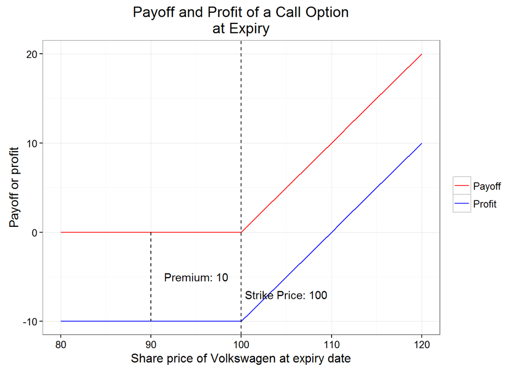

More formally put, the payoff $PO$ of the option at expiry, for a long position in a call option with a strike price of $K$ for a range of values of the underlying asset $S_T$ at expiry, is given by

$$PO_{Call} = max[0, S_T - K],$$

which is abbreviated to

$$PO_{Call} = (S_T - K) ^ +,$$

where $(x)^+$ is the equivalent to $max(x, 0)$, contrary $(x)^-$ equals $min(x, 0)$.

whereas the profit/loss $PL$ is subject to the premium, which is normally called $C$ for call-options and $P$ for put-options.

$$PL_{Call} = max[0, S_T - K] - C = max[- C, S_T - K - C] = (S_T - K) ^+ - C$$

# Put Option

On the other hand, we have a put option, which gives the buyer of the option the right to sell the underlying asset. A long-position in a put option looks like this:

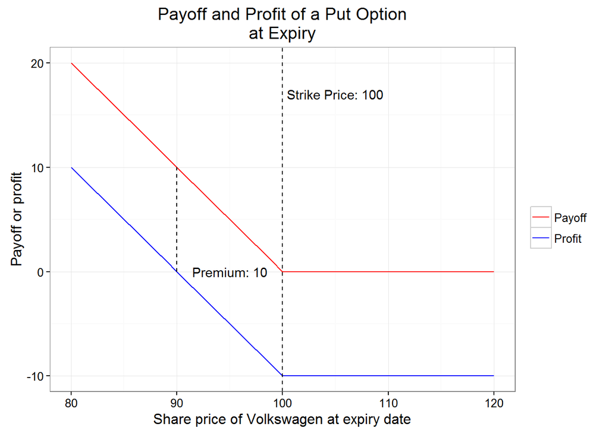

# Short positions

The short-position is given by a trader who sells the given option to the buyer. The payoff is the exact opposite of the long-position.

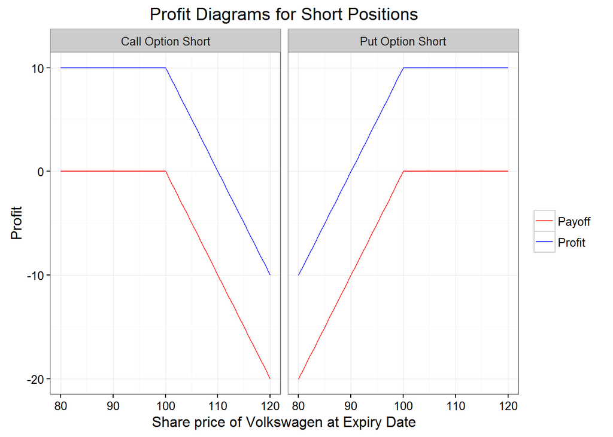

The payoffs for a short position in a call option is given by

$$PO_{Call, Short} = - max[0, S_T - K] = min[0, K - S_T] = (K-S_T)^-$$

with a profit-loss function of

$$PL_{Call, Short} = - max[0, S_T - K] + C = min[C, K - S_T + C] = (K-S_T)^- + C$$

# Call and Put, Long and Short Positions

To wrap up all profits for all combinations:

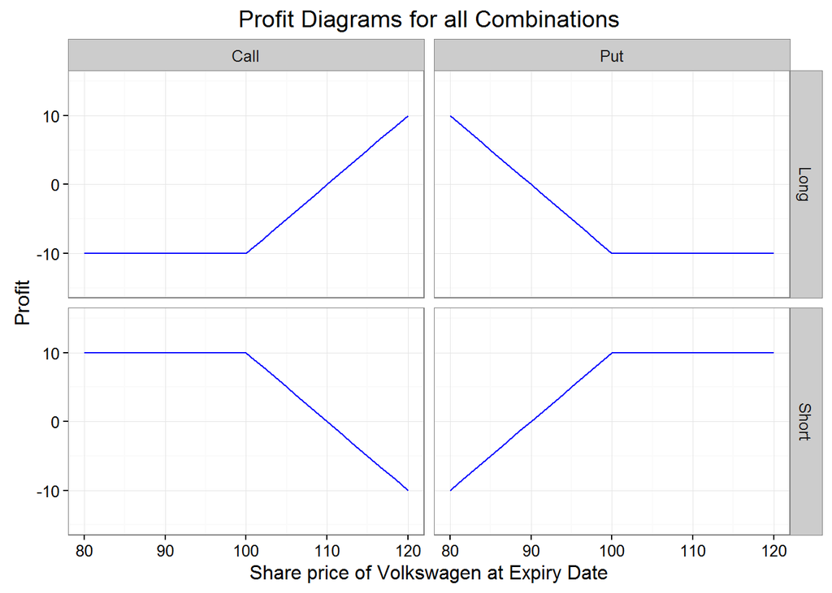

# Summary Payoffs

|  | Call | Put |
| --- | --- | --- |
| **Long** | $$(S_T-K)^+$$ | $$(K-S_T)^+$$ |
| **Short** | $$(K-S_T)^-$$ | $$(S_T-K)^-$$ |

Where $S_T$ stands for the price of the underlying asset at expiry, $K$ for the strike price, $(x)^+$ for $max(x, 0)$, and $(x)^-$ for $min(x, 0)$.

# Summary Profits

|  | Call | Put |
| --- | --- | --- |
| **Long** | $$(S_T-K)^+ - C$$ | $$(K-S_T)^+ - P$$ |
| **Short** | $$(K-S_T)^- + C$$ | $$(S_T-K)^- + P$$ |

Where $S_T$ stands for the price of the underlying asset at expiry, $K$ for the strike price, $C$ for the premium (the price) of the call, $P$ for the premium of the put, $(x)^+$ for $max(x, 0)$, and $(x)^-$ for $min(x, 0)$.